# Confirmatory analysis

## Replication study and hypotheses

This is a data analysis plan for the replication of:

Johnson, J. S., & Newport, E. L. (1989). Critical Period Effects in Second Language Learning: The Influence of Maturational State on the Acquisition of English as a Second Language. Cognitive Psychology, 21, 60–99.

The original test of the primary hypothesis is a independent t-test that compares the mean grammar test score across five groups: native English speakers and second-language speakers, classified by the age at which they started to learn English. A power analysis revealed that 545 participants were needed in each condition to achieve at least 80% power. Here I will document the analysis plan for this replication. A successful replication will find evidence of support for the alternate hypothesis, which is:

H1: There will be a negative relationship between the age of exposure to English and the performance in the test, lasting up to adulthood.

The null hypothesis being tested in the independent t-tests is:

H0: There will be no relationship between the age of exposure to English and the performance in the test.

## Load data

```r
data <- read_csv("~/Desktop/45160/Data/data.csv")
```

## Preliminary analysis

### Data Screening and cleaning

First the data will be screened for erroneous and missing values. The outcome in this study, mean score, is bounded between 0 and 276 and so any responses beyond this range will be replaced with a missing value.

```r
library(tidyverse)
library(psych)
library(naniar)
data <-
  data %>%
  replace_with_na(replace = list(~.score > 276, ~.score < 0))
describe(data)
```

|  | vars | n | mean | sd | median | trimmed | mad | min | max | range | skew | kurtosis | se |
| --- | --- | --- | --- | --- | --- | --- | --- | --- | --- | --- | --- | --- | --- |
| ...1 | 1 | 2725 | 1363.00 | 786.78 | 1363.00 | 1363.00 | 1009.65 | 1.00 | 2725 | 2724.00 | 0.00 | -1.20 | 15.07 |
| ID | 2 | 2725 | 273.00 | 157.36 | 273.00 | 273.00 | 201.63 | 1.00 | 545 | 544.00 | 0.00 | -1.20 | 3.01 |
| group* | 3 | 2725 | 3.00 | 1.41 | 3.00 | 3.00 | 1.48 | 1.00 | 5 | 4.00 | 0.00 | -1.30 | 0.03 |
| score | 4 | 2725 | 248.07 | 25.80 | 257.88 | 252.04 | 17.93 | 147.07 | 276 | 128.93 | -1.22 | 0.82 | 0.49 |

As this is an experimental study, any missing values will be removed listwise from the sample..

```r
drop_na(data)
```

[output not shown]

[output cut: 990 more lines]

### Summary statistics and distributions

I will inspect the means and standard deviations of each group in the study.

```r
describeBy(data,data$group)
```

```
 Descriptive statistics by group
group: eight_ten
```

|  | vars | n | mean | sd | median | trimmed | mad | min | max | range | skew | kurtosis | se |
| --- | --- | --- | --- | --- | --- | --- | --- | --- | --- | --- | --- | --- | --- |
| ...1 | 1 | 545 | 1363.00 | 157.47 | 1363.0 | 1363.00 | 201.63 | 1091.00 | 1635.00 | 544.00 | 0.00 | -1.21 | 6.75 |
| ID | 2 | 545 | 273.00 | 157.47 | 273.0 | 273.00 | 201.63 | 1.00 | 545.00 | 544.00 | 0.00 | -1.21 | 6.75 |
| group* | 3 | 545 | 1.00 | 0.00 | 1.0 | 1.00 | 0.00 | 1.00 | 1.00 | 0.00 | NaN | NaN | 0.00 |
| score | 4 | 545 | 256.51 | 6.00 | 256.6 | 256.56 | 5.82 | 235.44 | 272.22 | 36.77 | -0.14 | 0.02 | 0.26 |

```
-----------------------------------------------
group: eleven_fifteen
```

|  | vars | n | mean | sd | median | trimmed | mad | min | max | range | skew | kurtosis | se |
| --- | --- | --- | --- | --- | --- | --- | --- | --- | --- | --- | --- | --- | --- |
| ...1 | 1 | 545 | 1908.00 | 157.47 | 1908.00 | 1908.00 | 201.63 | 1636.00 | 2180 | 544.00 | 0.00 | -1.21 | 6.75 |
| ID | 2 | 545 | 273.00 | 157.47 | 273.00 | 273.00 | 201.63 | 1.00 | 545 | 544.00 | 0.00 | -1.21 | 6.75 |
| group* | 3 | 545 | 1.00 | 0.00 | 1.00 | 1.00 | 0.00 | 1.00 | 1 | 0.00 | NaN | NaN | 0.00 |
| score | 4 | 545 | 235.67 | 13.08 | 236.16 | 235.48 | 13.97 | 199.27 | 276 | 76.73 | 0.12 | -0.32 | 0.56 |

```
-----------------------------------------------
group: native
```

|  | vars | n | mean | sd | median | trimmed | mad | min | max | range | skew | kurtosis | se |
| --- | --- | --- | --- | --- | --- | --- | --- | --- | --- | --- | --- | --- | --- |
| ...1 | 1 | 545 | 273.00 | 157.47 | 273.00 | 273.0 | 201.63 | 1.00 | 545 | 544.00 | 0.00 | -1.21 | 6.75 |
| ID | 2 | 545 | 273.00 | 157.47 | 273.00 | 273.0 | 201.63 | 1.00 | 545 | 544.00 | 0.00 | -1.21 | 6.75 |
| group* | 3 | 545 | 1.00 | 0.00 | 1.00 | 1.0 | 0.00 | 1.00 | 1 | 0.00 | NaN | NaN | 0.00 |
| score | 4 | 545 | 268.64 | 2.93 | 268.72 | 268.7 | 2.92 | 259.78 | 276 | 16.22 | -0.18 | 0.01 | 0.13 |

```
-----------------------------------------------
group: seventeen_thirtynine
```

|  | vars | n | mean | sd | median | trimmed | mad | min | max | range | skew | kurtosis | se |
| --- | --- | --- | --- | --- | --- | --- | --- | --- | --- | --- | --- | --- | --- |
| ...1 | 1 | 545 | 2453.0 | 157.47 | 2453.00 | 2453.00 | 201.63 | 2181.00 | 2725 | 544.00 | 0.00 | -1.21 | 6.75 |
| ID | 2 | 545 | 273.0 | 157.47 | 273.00 | 273.00 | 201.63 | 1.00 | 545 | 544.00 | 0.00 | -1.21 | 6.75 |
| group* | 3 | 545 | 1.0 | 0.00 | 1.00 | 1.00 | 0.00 | 1.00 | 1 | 0.00 | NaN | NaN | 0.00 |
| score | 4 | 545 | 210.2 | 23.89 | 210.67 | 209.94 | 22.28 | 147.07 | 276 | 128.93 | 0.09 | 0.04 | 1.02 |

```
-----------------------------------------------
group: three_seven
```

|  | vars | n | mean | sd | median | trimmed | mad | min | max | range | skew | kurtosis | se |
| --- | --- | --- | --- | --- | --- | --- | --- | --- | --- | --- | --- | --- | --- |
| ...1 | 1 | 545 | 818.00 | 157.47 | 818.00 | 818.0 | 201.63 | 546.00 | 1090 | 544.00 | 0.00 | -1.21 | 6.75 |
| ID | 2 | 545 | 273.00 | 157.47 | 273.00 | 273.0 | 201.63 | 1.00 | 545 | 544.00 | 0.00 | -1.21 | 6.75 |
| group* | 3 | 545 | 1.00 | 0.00 | 1.00 | 1.0 | 0.00 | 1.00 | 1 | 0.00 | NaN | NaN | 0.00 |
| score | 4 | 545 | 269.31 | 2.86 | 269.34 | 269.3 | 2.86 | 258.24 | 276 | 17.76 | -0.02 | -0.11 | 0.12 |

Then I will create a plot for the distributions of each group.

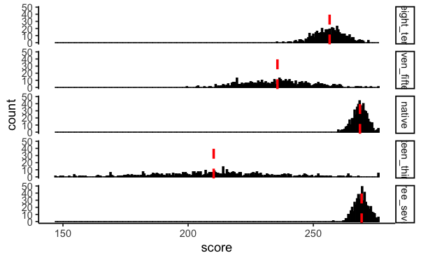

```r
library(ggplot2)
library(plyr)
## Find mean for each condition

means <- ddply(data, "group", summarise, score.mean=mean(score))

## Plot distributions

plot1 <- ggplot(data, aes(x=score)) + geom_histogram(binwidth=.5, colour="black", fill="white") +
    facet_grid(group ~ .) +
    geom_vline(data=means, aes(xintercept=score.mean),
               linetype="dashed", size=1, colour="red") + theme_classic()

print(plot1)


## Save plot
ggsave(file="~/Desktop/45160/Plots/plot_1.png")
```

And finally create an APA table with the mean and sd for each condition.

```r
library(apaTables)
apa.1way.table(iv=group,dv=score,data=data,filename="~/Desktop/45160/Tables/table_1.doc",table.number = 1)
```

```
Table 1

Descriptive statistics for score as a function of group.
```

| group | M | SD |
| --- | --- | --- |
| eight_ten | 256.51 | 6.00 |
| eleven_fifteen | 235.67 | 13.08 |
| native | 268.64 | 2.93 |
| seventeen_thirtynine | 210.20 | 23.89 |
| three_seven | 269.31 | 2.86 |

```
Note. M and SD represent mean and standard deviation, respectively.
```

In order to perform 4 independent t-tests, I will use the split() function in order to split the ‘data’ data frame into 5 sub-data frames for each group. I will then combine the data frames two by two so that I can perform a t-test on each pair.

```r
list_of_dfs <- split(data, data$group)
df_native <- list_of_dfs$native
df_three_seven <- list_of_dfs$three_seven
df_eight_ten <- list_of_dfs$eight_ten
df_eleven_fifteen <- list_of_dfs$eleven_fifteen
df_seventeen_thirynine <- list_of_dfs$seventeen_thirtynine
df_native
```

| ...1 | ID | group | score |
| --- | --- | --- | --- |
| 1 | 1 | native | 268.6612 |
| 2 | 2 | native | 269.0310 |
| 3 | 3 | native | 267.8530 |
| 4 | 4 | native | 273.0263 |
| 5 | 5 | native | 263.7414 |
| 6 | 6 | native | 269.3078 |
| 7 | 7 | native | 267.4663 |
| 8 | 8 | native | 269.2921 |
| 9 | 9 | native | 273.2877 |
| 10 | 10 | native | 265.9628 |

[output cut: 535 more lines]

```r
df_three_seven
```

| ...1 | ID | group | score |
| --- | --- | --- | --- |
| 546 | 1 | three_seven | 270.7285 |
| 547 | 2 | three_seven | 271.0897 |
| 548 | 3 | three_seven | 264.7144 |
| 549 | 4 | three_seven | 267.6481 |
| 550 | 5 | three_seven | 274.2297 |
| 551 | 6 | three_seven | 269.4446 |
| 552 | 7 | three_seven | 268.0334 |
| 553 | 8 | three_seven | 268.6241 |
| 554 | 9 | three_seven | 272.7404 |
| 555 | 10 | three_seven | 266.6257 |

[output cut: 535 more lines]

```r
df_eight_ten
```

| ...1 | ID | group | score |
| --- | --- | --- | --- |
| 1091 | 1 | eight_ten | 263.8263 |
| 1092 | 2 | eight_ten | 254.0857 |
| 1093 | 3 | eight_ten | 258.9683 |
| 1094 | 4 | eight_ten | 250.8852 |
| 1095 | 5 | eight_ten | 267.6607 |
| 1096 | 6 | eight_ten | 262.6449 |
| 1097 | 7 | eight_ten | 262.9951 |
| 1098 | 8 | eight_ten | 265.8307 |
| 1099 | 9 | eight_ten | 261.0958 |
| 1100 | 10 | eight_ten | 260.8412 |

[output cut: 535 more lines]

```r
df_eleven_fifteen
```

| ...1 | ID | group | score |
| --- | --- | --- | --- |
| 1636 | 1 | eleven_fifteen | 216.9256 |
| 1637 | 2 | eleven_fifteen | 221.4286 |
| 1638 | 3 | eleven_fifteen | 226.9062 |
| 1639 | 4 | eleven_fifteen | 214.2332 |
| 1640 | 5 | eleven_fifteen | 240.5762 |
| 1641 | 6 | eleven_fifteen | 241.4103 |
| 1642 | 7 | eleven_fifteen | 227.2968 |
| 1643 | 8 | eleven_fifteen | 246.5419 |
| 1644 | 9 | eleven_fifteen | 242.0610 |
| 1645 | 10 | eleven_fifteen | 220.4628 |

[output cut: 535 more lines]

```r
df_seventeen_thirynine
```

| ...1 | ID | group | score |
| --- | --- | --- | --- |
| 2181 | 1 | seventeen_thirtynine | 156.8414 |
| 2182 | 2 | seventeen_thirtynine | 202.0654 |
| 2183 | 3 | seventeen_thirtynine | 215.3258 |
| 2184 | 4 | seventeen_thirtynine | 154.4354 |
| 2185 | 5 | seventeen_thirtynine | 205.1096 |
| 2186 | 6 | seventeen_thirtynine | 251.7505 |
| 2187 | 7 | seventeen_thirtynine | 164.3447 |
| 2188 | 8 | seventeen_thirtynine | 203.5631 |
| 2189 | 9 | seventeen_thirtynine | 188.0933 |
| 2190 | 10 | seventeen_thirtynine | 227.1365 |

[output cut: 535 more lines]

The following code will combine the data frames two by two, producing 4 data frames ready to t-test.

```r
df_ttest1<- rbind(df_native, df_three_seven)
df_ttest2 <- rbind(df_three_seven,df_eight_ten)
df_ttest3 <- rbind(df_eight_ten, df_eleven_fifteen)
df_ttest4 <- rbind(df_eleven_fifteen, df_seventeen_thirynine)
df_ttest1
```

| ...1 | ID | group | score |
| --- | --- | --- | --- |
| 1 | 1 | native | 268.6612 |
| 2 | 2 | native | 269.0310 |
| 3 | 3 | native | 267.8530 |
| 4 | 4 | native | 273.0263 |
| 5 | 5 | native | 263.7414 |
| 6 | 6 | native | 269.3078 |
| 7 | 7 | native | 267.4663 |
| 8 | 8 | native | 269.2921 |
| 9 | 9 | native | 273.2877 |
| 10 | 10 | native | 265.9628 |

[output cut: 990 more lines]

```r
df_ttest2
```

| ...1 | ID | group | score |
| --- | --- | --- | --- |
| 546 | 1 | three_seven | 270.7285 |
| 547 | 2 | three_seven | 271.0897 |
| 548 | 3 | three_seven | 264.7144 |
| 549 | 4 | three_seven | 267.6481 |
| 550 | 5 | three_seven | 274.2297 |
| 551 | 6 | three_seven | 269.4446 |
| 552 | 7 | three_seven | 268.0334 |
| 553 | 8 | three_seven | 268.6241 |
| 554 | 9 | three_seven | 272.7404 |
| 555 | 10 | three_seven | 266.6257 |

[output cut: 990 more lines]

```r
df_ttest3
```

| ...1 | ID | group | score |
| --- | --- | --- | --- |
| 1091 | 1 | eight_ten | 263.8263 |
| 1092 | 2 | eight_ten | 254.0857 |
| 1093 | 3 | eight_ten | 258.9683 |
| 1094 | 4 | eight_ten | 250.8852 |
| 1095 | 5 | eight_ten | 267.6607 |
| 1096 | 6 | eight_ten | 262.6449 |
| 1097 | 7 | eight_ten | 262.9951 |
| 1098 | 8 | eight_ten | 265.8307 |
| 1099 | 9 | eight_ten | 261.0958 |
| 1100 | 10 | eight_ten | 260.8412 |

[output cut: 990 more lines]

```r
df_ttest4
```

| ...1 | ID | group | score |
| --- | --- | --- | --- |
| 1636 | 1 | eleven_fifteen | 216.9256 |
| 1637 | 2 | eleven_fifteen | 221.4286 |
| 1638 | 3 | eleven_fifteen | 226.9062 |
| 1639 | 4 | eleven_fifteen | 214.2332 |
| 1640 | 5 | eleven_fifteen | 240.5762 |
| 1641 | 6 | eleven_fifteen | 241.4103 |
| 1642 | 7 | eleven_fifteen | 227.2968 |
| 1643 | 8 | eleven_fifteen | 246.5419 |
| 1644 | 9 | eleven_fifteen | 242.0610 |
| 1645 | 10 | eleven_fifteen | 220.4628 |

[output cut: 990 more lines]

## Confirmatory analysis

The next step is to conduct the independent samples t-test for the primary confirmatory hypothesis testing as listed in the data analysis plan.

### T-test 1

I’ll perform Levene’s Test for Homogeneity of Variance to test the equality of variances between the groups.

```r
library(car)
levene_ttest1 <- leveneTest(score ~ group, data=df_ttest1)
levene_ttest1
```

```
Levene's Test for Homogeneity of Variance (center = median)
        Df F value Pr(>F)
group    1  0.1128  0.737
      1088
```

The p-value is 0.737, which is greater than a 0.05 significance level. I cannot reject the hypothesis of equal variances, so I will use the var.equal argument set to TRUE in the t-test.

```r
library(MKinfer)
t.test(score ~ group, data=df_ttest1, var.equal=TRUE, paired=FALSE)
```

```
    Two Sample t-test

data:  score by group
t = -3.7965, df = 1088, p-value = 0.0001548
alternative hypothesis: true difference in means between group native and group three_seven is not equal to 0
95 percent confidence interval:
 -1.0094084 -0.3215379
sample estimates:
     mean in group native mean in group three_seven
                 268.6403                  269.3058
```

```r
boot.t.test(score ~ group, data=df_ttest1, var.equal=TRUE, R = 5000)
```

```
    Bootstrap Two Sample t-test

data:  score by group
bootstrap p-value < 2.2e-16
bootstrap difference of means (SE) = -0.6672654 (0.176316)
95 percent bootstrap percentile confidence interval:
 -0.9977763 -0.3285898

Results without bootstrap:
t = -3.7965, df = 1088, p-value = 0.0001548
alternative hypothesis: true difference in means is not equal to 0
95 percent confidence interval:
 -1.0094084 -0.3215379
sample estimates:
     mean in group native mean in group three_seven
                 268.6403                  269.3058
```

Now I will calculate the effect size for the experimental condition.

```r
library(rstatix)
cohens_d(df_ttest1, score ~ group,  var.equal = TRUE)
```

|  | .y. | group1 | group2 | effsize | n1 | n2 | magnitude |
| --- | --- | --- | --- | --- | --- | --- | --- |
| 1 | score | native | three_seven | -0.2299863 | 545 | 545 | small |

#### Tables and figures for reporting

To report the results from the independent t-test I will visualize the means and 95% confidence intervals for each condition using a bar chart with error bars.

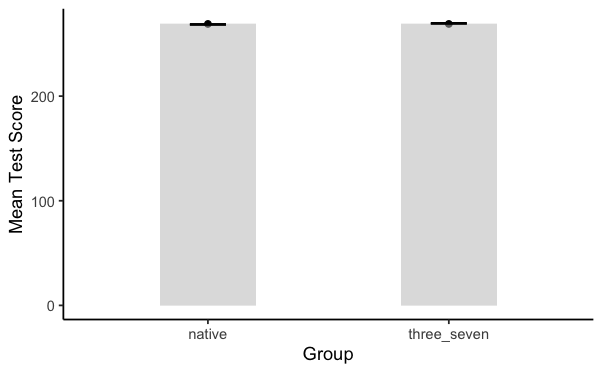

```r
library(rcompanion)
sum <- groupwiseMean(score ~ group, data=df_ttest1,conf   = 0.95,digits = 3)
qplot(x    = group ,
      y    = Mean,
      data = sum) +

geom_bar(stat ="identity",
         fill = "gray", width = .40, alpha=.5
        ) +

geom_errorbar(aes(ymin  = Trad.lower,
                  ymax  = Trad.upper,
                  width = 0.15)) +
  xlab("Group") +
  ylab("Mean Test Score")+
  theme_classic()

ggsave(file="~/Desktop/45160/Plots/plot_2.png")
```

### T-test 2

I’ll perform Levene’s Test for Homogeneity of Variance to test the equality of variances between the groups.

```r
library(car)
levene_ttest2 <- leveneTest(score ~ group, data=df_ttest2)
levene_ttest2
```

```
Levene's Test for Homogeneity of Variance (center = median)
        Df F value    Pr(>F)
group    1  215.71 < 2.2e-16 ***
      1088
---
Signif. codes:  0 ‘***’ 0.001 ‘**’ 0.01 ‘*’ 0.05 ‘.’ 0.1 ‘ ’ 1
```

The p-value is smaller than 2.2e-16, which is much lower than a 0.05 significance level. There is strong evidence to reject the hypothesis of equal variances, so I will use a Welch’s t-test.

```r
library(MKinfer)
t.test(score ~ group, data=df_ttest2, var.equal=FALSE, paired=FALSE)
```

```
    Welch Two Sample t-test

data:  score by group
t = -44.937, df = 778.83, p-value < 2.2e-16
alternative hypothesis: true difference in means between group eight_ten and group three_seven is not equal to 0
95 percent confidence interval:
 -13.35296 -12.23517
sample estimates:
  mean in group eight_ten mean in group three_seven
                 256.5118                  269.3058
```

```r
boot.t.test(score ~ group, data=df_ttest2, var.equal=FALSE, R = 5000)
```

```
    Bootstrap Welch Two Sample t-test

data:  score by group
bootstrap p-value < 2.2e-16
bootstrap difference of means (SE) = -12.80071 (0.2844443)
95 percent bootstrap percentile confidence interval:
 -13.37069 -12.24750

Results without bootstrap:
t = -44.937, df = 778.83, p-value < 2.2e-16
alternative hypothesis: true difference in means is not equal to 0
95 percent confidence interval:
 -13.35296 -12.23517
sample estimates:
  mean in group eight_ten mean in group three_seven
                 256.5118                  269.3058
```

Now I will calculate the effect size for the experimental condition.

```r
library(rstatix)
cohens_d(df_ttest2, score ~ group,  var.equal = FALSE)
```

|  | .y. | group1 | group2 | effsize | n1 | n2 | magnitude |
| --- | --- | --- | --- | --- | --- | --- | --- |
| 1 | score | eight_ten | three_seven | -2.722194 | 545 | 545 | large |

#### Tables and figures for reporting

To report the results from the independent t-test I will visualize the means and 95% confidence intervals for each condition using a bar chart with error bars.

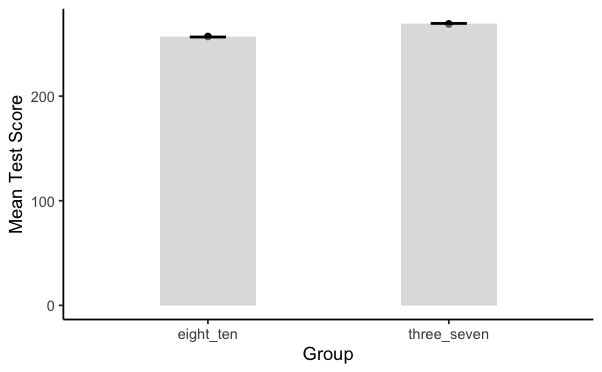

```r
library(rcompanion)
sum <- groupwiseMean(score ~ group, data=df_ttest2,conf   = 0.95,digits = 3)
qplot(x    = group ,
      y    = Mean,
      data = sum) +

geom_bar(stat ="identity",
         fill = "gray", width = .40, alpha=.5
        ) +

geom_errorbar(aes(ymin  = Trad.lower,
                  ymax  = Trad.upper,
                  width = 0.15)) +
  xlab("Group") +
  ylab("Mean Test Score")+
  theme_classic()

ggsave(file="~/Desktop/45160/Plots/plot_3.png")
```

### T-test 3

I’ll perform Levene’s Test for Homogeneity of Variance to test the equality of variances between the groups.

```r
library(car)
levene_ttest3 <- leveneTest(score ~ group, data=df_ttest3)
levene_ttest3
```

```
Levene's Test for Homogeneity of Variance (center = median)
        Df F value    Pr(>F)
group    1  255.52 < 2.2e-16 ***
      1088
---
Signif. codes:  0 ‘***’ 0.001 ‘**’ 0.01 ‘*’ 0.05 ‘.’ 0.1 ‘ ’ 1
```

The p-value is smaller than 2.2e-16, which is much lower than a 0.05 significance level. There is strong evidence to reject the hypothesis of equal variances, so I will use a Welch’s t-test.

```r
library(MKinfer)
t.test(score ~ group, data=df_ttest3, var.equal=FALSE, paired=FALSE)
```

```
    Welch Two Sample t-test

data:  score by group
t = 33.811, df = 763.28, p-value < 2.2e-16
alternative hypothesis: true difference in means between group eight_ten and group eleven_fifteen is not equal to 0
95 percent confidence interval:
 19.63138 22.05150
sample estimates:
     mean in group eight_ten mean in group eleven_fifteen
                    256.5118                     235.6703
```

```r
boot.t.test(score ~ group, data=df_ttest3, var.equal=FALSE, R = 5000)
```

```
    Bootstrap Welch Two Sample t-test

data:  score by group
bootstrap p-value < 2.2e-16
bootstrap difference of means (SE) = 20.84898 (0.6155828)
95 percent bootstrap percentile confidence interval:
 19.63933 22.07294

Results without bootstrap:
t = 33.811, df = 763.28, p-value < 2.2e-16
alternative hypothesis: true difference in means is not equal to 0
95 percent confidence interval:
 19.63138 22.05150
sample estimates:
     mean in group eight_ten mean in group eleven_fifteen
                    256.5118                     235.6703
```

Now I will calculate the effect size for the experimental condition.

```r
library(rstatix)
cohens_d(df_ttest3, score ~ group,  var.equal = FALSE)
```

|  | .y. | group1 | group2 | effsize | n1 | n2 | magnitude |
| --- | --- | --- | --- | --- | --- | --- | --- |
| 1 | score | eight_ten | eleven_fifteen | 2.04821 | 545 | 545 | large |

#### Tables and figures for reporting

To report the results from the independent t-test I will visualize the means and 95% confidence intervals for each condition using a bar chart with error bars.

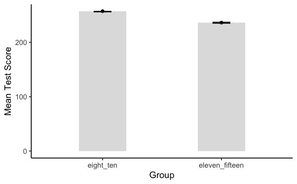

```r
library(rcompanion)
sum <- groupwiseMean(score ~ group, data=df_ttest3,conf   = 0.95,digits = 3)
qplot(x    = group ,
      y    = Mean,
      data = sum) +

geom_bar(stat ="identity",
         fill = "gray", width = .40, alpha=.5
        ) +

geom_errorbar(aes(ymin  = Trad.lower,
                  ymax  = Trad.upper,
                  width = 0.15)) +
  xlab("Group") +
  ylab("Mean Test Score")+
  theme_classic()

ggsave(file="~/Desktop/45160/Plots/plot_4.png")
```

### T-test 4

I’ll perform Levene’s Test for Homogeneity of Variance to test the equality of variances between the groups.

```r
library(car)
levene_ttest4 <- leveneTest(score ~ group, data=df_ttest4)
levene_ttest4
```

```
Levene's Test for Homogeneity of Variance (center = median)
        Df F value    Pr(>F)
group    1   122.2 < 2.2e-16 ***
      1088
---
Signif. codes:  0 ‘***’ 0.001 ‘**’ 0.01 ‘*’ 0.05 ‘.’ 0.1 ‘ ’ 1
```

The p-value is smaller than 2.2e-16, which is much lower than a 0.05 significance level. There is strong evidence to reject the hypothesis of equal variances, so I will use a Welch’s t-test.

```r
library(MKinfer)
t.test(score ~ group, data=df_ttest4, var.equal=FALSE, paired=FALSE)
```

```
    Welch Two Sample t-test

data:  score by group
t = 21.827, df = 843.18, p-value < 2.2e-16
alternative hypothesis: true difference in means between group eleven_fifteen and group seventeen_thirtynine is not equal to 0
95 percent confidence interval:
 23.17681 27.75704
sample estimates:
      mean in group eleven_fifteen
                          235.6703
mean in group seventeen_thirtynine
                          210.2034
```

```r
boot.t.test(score ~ group, data=df_ttest4, var.equal=FALSE, R = 5000)
```

```
    Bootstrap Welch Two Sample t-test

data:  score by group
bootstrap p-value < 2.2e-16
bootstrap difference of means (SE) = 25.47509 (1.165353)
95 percent bootstrap percentile confidence interval:
 23.20884 27.67890

Results without bootstrap:
t = 21.827, df = 843.18, p-value < 2.2e-16
alternative hypothesis: true difference in means is not equal to 0
95 percent confidence interval:
 23.17681 27.75704
sample estimates:
      mean in group eleven_fifteen
                          235.6703
mean in group seventeen_thirtynine
                          210.2034
```

Now I will calculate the effect size for the experimental condition.

```r
library(rstatix)
cohens_d(df_ttest4, score ~ group,  var.equal = FALSE)
```

|  | .y. | group1 | group2 | effsize | n1 | n2 | magnitude |
| --- | --- | --- | --- | --- | --- | --- | --- |
| 1 | score | eleven_fifteen | seventeen_thirtynine | 1.322231 | 545 | 545 | large |

#### Tables and figures for reporting

To report the results from the independent t-test I will visualize the means and 95% confidence intervals for each condition using a bar chart with error bars.

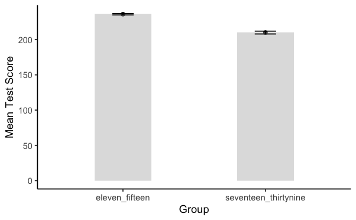

```r
library(rcompanion)
sum <- groupwiseMean(score ~ group, data=df_ttest4,conf   = 0.95,digits = 3)
qplot(x    = group ,
      y    = Mean,
      data = sum) +

geom_bar(stat ="identity",
         fill = "gray", width = .40, alpha=.5
        ) +

geom_errorbar(aes(ymin  = Trad.lower,
                  ymax  = Trad.upper,
                  width = 0.15)) +
  xlab("Group") +
  ylab("Mean Test Score")+
  theme_classic()

ggsave(file="~/Desktop/45160/Plots/plot_5.png")
```